# RepData Peer Assesment 1

HrKa

20 Oktober 2017

# Loading and preprocessing the data

1. Load the data (i.e. read.csv())

```r
data_activity = read.csv("activity.csv")
```

2. Process/transform the data (if necessary) into a format suitable for your analysis

```r
steps_per_day =
  aggregate(steps ~ date,data = data_activity, FUN=sum, na.rm=TRUE)

steps_per_interval_on_average_day =
  aggregate(steps ~ interval,data = data_activity,FUN=mean, na.rm=TRUE)
```

# What is mean total number of steps taken per day?

1. Make a histogram of the total number of steps taken each day

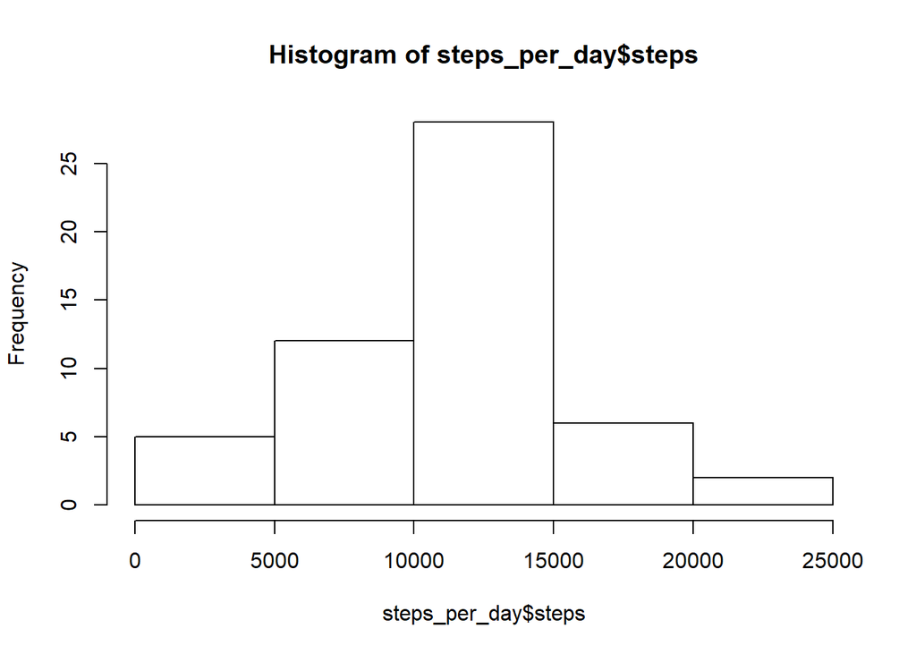

```r
hist(steps_per_day$steps)
```

2. Calculate and report the mean and median total number of steps taken per day

```r
mean(steps_per_day$steps)
```

```
## [1] 10766.19
```

```r
median(steps_per_day$steps)
```

```
## [1] 10765
```

# What is the average daily activity pattern?

1. Make a time series plot (i.e. type = “l”) of the 5-minute interval (x-axis) and the average number of steps taken, averaged across all days (y-axis)

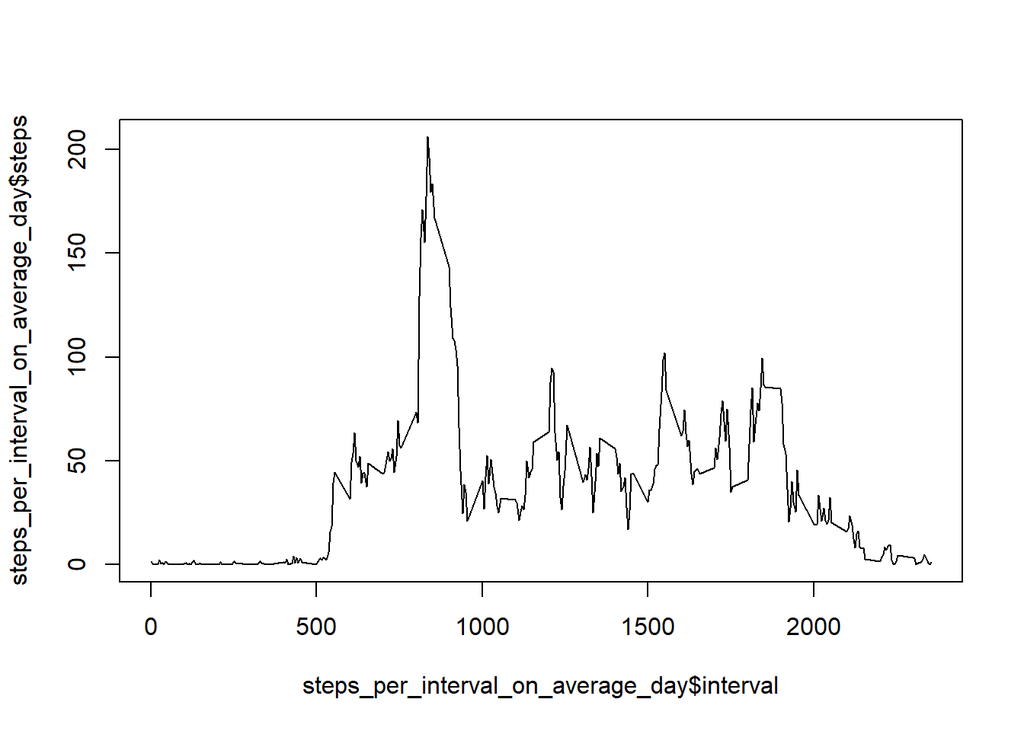

```r
plot(x = steps_per_interval_on_average_day$interval , y = steps_per_interval_on_average_day$steps, type = "l")
```

2. Which 5-minute interval, on average across all the days in the dataset, contains the maximum number of steps?

```r
steps_per_interval_on_average_day$interval[which.max(steps_per_interval_on_average_day$steps)]
```

```
## [1] 835
```

# Imputing missing values

1. Calculate and report the total number of missing values in the dataset (i.e. the total number of rows with NAs)

```r
sum(is.na(data_activity$steps))
```

```
## [1] 2304
```

2. Devise a strategy for filling in all of the missing values in the dataset. The strategy does not need to be sophisticated. For example, you could use the mean/median for that day, or the mean for that 5-minute interval, etc.

*Strategy: for all missing values of “steps” find the respective “interval” and replace the missing value with the average steps over all days for this interval*

3. Create a new dataset that is equal to the original dataset but with the missing data filled in.

```r
data_activity_new = data_activity
for(i in 1:length(data_activity$steps)){
  if (is.na(data_activity$steps[i]))
    data_activity_new$steps[i] =
     steps_per_interval_on_average_day[steps_per_interval_on_average_day$interval==data_activity$interval[i],2]
}
```

4. Make a histogram of the total number of steps taken each day and Calculate and report the mean and median total number of steps taken per day. Do these values differ from the estimates from the first part of the assignment? What is the impact of imputing missing data on the estimates of the total daily number of steps?

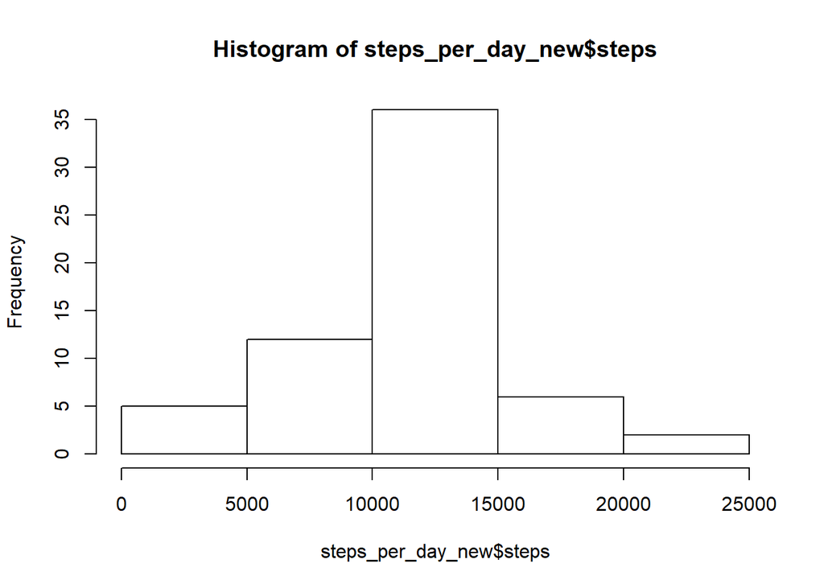

```r
steps_per_day_new =
    aggregate(steps ~ date,data = data_activity_new, FUN=sum)

hist(steps_per_day_new$steps)
```

```r
mean(steps_per_day_new$steps)
```

```
## [1] 10766.19
```

```r
median(steps_per_day_new$steps)
```

```
## [1] 10766.19
```

```r
sprintf("Difference in mean: %f - %f = %f",
        mean(steps_per_day$steps),mean(steps_per_day_new$steps),
        mean(steps_per_day$steps)-mean(steps_per_day_new$steps))
```

```
## [1] "Difference in mean: 10766.188679 - 10766.188679 = 0.000000"
```

```r
sprintf("Difference in median: %f - %f = %f",
       median(steps_per_day$steps),median(steps_per_day_new$steps),
       median(steps_per_day$steps)-median(steps_per_day_new$steps))
```

```
## [1] "Difference in median: 10765.000000 - 10766.188679 = -1.188679"
```